# Synthetic Canadians: Comparing Synthetic Survey Data Generators

2021 Canadian Election Study — Political Attitudes Validation Study

Author

Synthetic Opinion Lab

Published

March 14, 2026

## Overview

This report validates three synthetic data generation approaches against the **2021 Canadian Election Study (CES21)**, combining campaign period (CPS) and post-election (PES) survey modules (n = 9,418 complete cases from 20,968 total respondents).

The 21 variables span: **democratic satisfaction**, **political efficacy** (3 items), **economic evaluations** (2 items), **populism** (3-item battery), **institutional confidence** (4 items), **immigration attitudes** (2 items), **social conservatism** (3 items), **income inequality**, **party identification**, and **actual vote choice**.

Three generators are compared:

| Generator | N synthetic | Overall quality score |
| --- | --- | --- |
| **LLM** (Qwen2.5-7B-Instruct) | 100 | 0.606 |
| **IRT** (Graded Response Model) | 1,000 | 0.485 |
| **Agent** (Opinion dynamics) | 500 | 0.559 |

Table 1: Summary statistics across all 21 variables

|  | Real (n=9,418) | IRT (n=1,000) | LLM (n=100) | Agent (n=500) |
| --- | --- | --- | --- | --- |
| N | 9418.000000 | 1000.000000 | 100.000000 | 500.000000 |
| Grand mean | 2.700000 | 2.990000 | 2.270000 | 2.390000 |
| Grand SD | 1.100000 | 0.900000 | 0.750000 | 1.140000 |

## Mean Responses by Variable

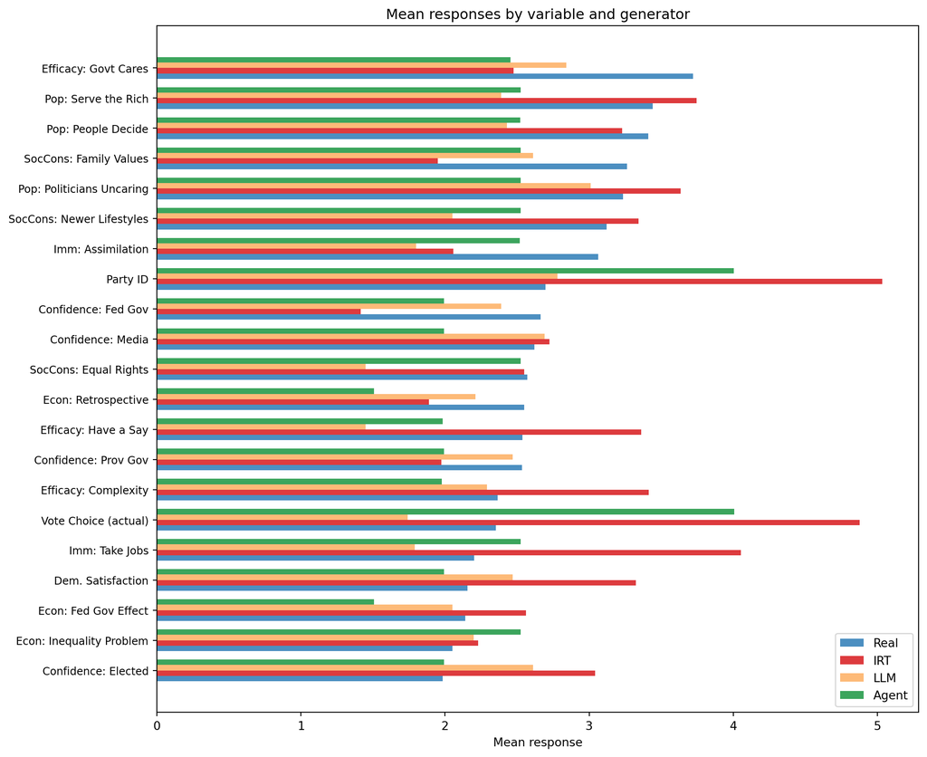

Table 2: Mean responses by variable and generator

|  | Real | IRT | LLM | Agent |
| --- | --- | --- | --- | --- |
| Confidence: Elected | 1.980000 | 3.040000 | 2.610000 | 1.990000 |
| Econ: Inequality Problem | 2.050000 | 2.230000 | 2.200000 | 2.520000 |
| Econ: Fed Gov Effect | 2.140000 | 2.560000 | 2.050000 | 1.510000 |
| Dem. Satisfaction | 2.150000 | 3.320000 | 2.470000 | 1.990000 |
| Imm: Take Jobs | 2.200000 | 4.050000 | 1.790000 | 2.520000 |
| Vote Choice (actual) | 2.350000 | 4.880000 | 1.740000 | 4.010000 |
| Efficacy: Complexity | 2.370000 | 3.410000 | 2.290000 | 1.980000 |
| Confidence: Prov Gov | 2.540000 | 1.970000 | 2.470000 | 1.990000 |
| Efficacy: Have a Say | 2.540000 | 3.360000 | 1.450000 | 1.980000 |
| Econ: Retrospective | 2.550000 | 1.890000 | 2.210000 | 1.510000 |
| SocCons: Equal Rights | 2.570000 | 2.550000 | 1.450000 | 2.530000 |
| Confidence: Media | 2.620000 | 2.720000 | 2.690000 | 1.990000 |
| Confidence: Fed Gov | 2.660000 | 1.420000 | 2.390000 | 1.990000 |
| Party ID | 2.700000 | 5.040000 | 2.780000 | 4.000000 |
| Imm: Assimilation | 3.060000 | 2.060000 | 1.800000 | 2.520000 |
| SocCons: Newer Lifestyles | 3.120000 | 3.340000 | 2.050000 | 2.520000 |
| Pop: Politicians Uncaring | 3.240000 | 3.640000 | 3.010000 | 2.520000 |
| SocCons: Family Values | 3.260000 | 1.950000 | 2.610000 | 2.530000 |
| Pop: People Decide | 3.410000 | 3.230000 | 2.430000 | 2.520000 |
| Pop: Serve the Rich | 3.440000 | 3.740000 | 2.390000 | 2.520000 |
| Efficacy: Govt Cares | 3.720000 | 2.470000 | 2.840000 | 2.450000 |

## Response Distributions

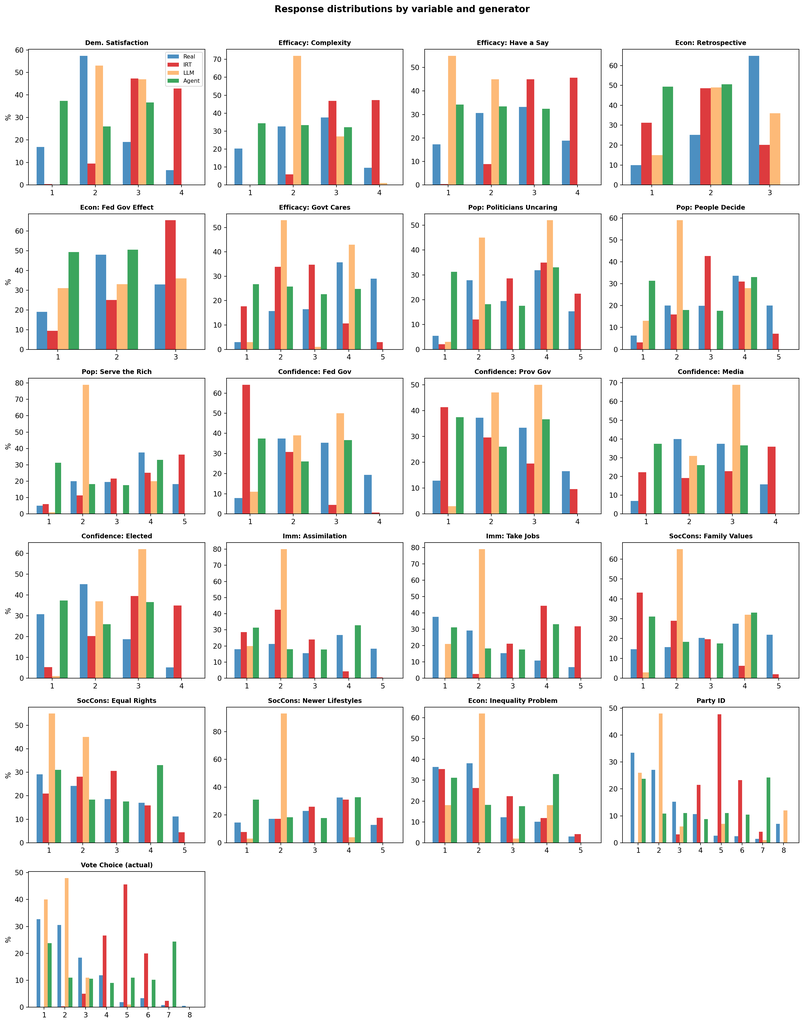

## Standard Deviations

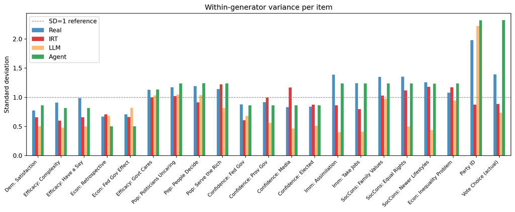

## Correlation Structure

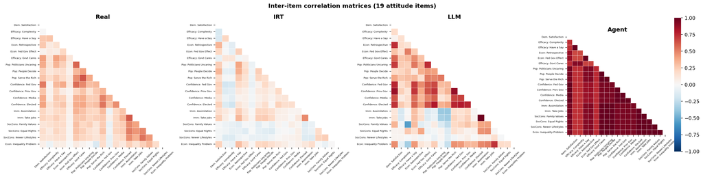

```
Frobenius distance from real correlation matrix:
  IRT                 : Frobenius = 4.62, r(lower tri) = 0.141
  LLM                 : Frobenius = 4.85, r(lower tri) = 0.410
  Agent               : Frobenius = 12.75, r(lower tri) = 0.185
```

## K-Means Clustering (k=3)

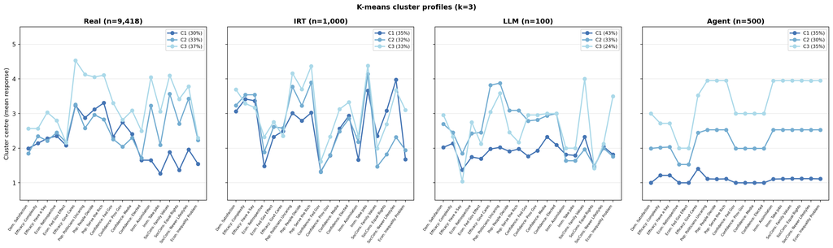

## Regression Replication: Actual Vote Predictors

Logistic regression predicting Conservative vs. Liberal actual vote from attitude items.

Table 3: Logistic regression: Conservative vs. Liberal actual vote (standardised)

|  | Real | LLM | Agent |
| --- | --- | --- | --- |
| Confidence: Fed Gov | 1.759000 | 1.852000 | 0.000000 |
| Imm: Assimilation | 0.402000 | 0.830000 | 0.420000 |
| SocCons: Family Values | 0.520000 | 2.350000 | 0.941000 |
| Econ: Inequality Problem | 0.605000 | 0.581000 | 0.505000 |
| Econ: Fed Gov Effect | -0.105000 | -0.180000 | 0.000000 |

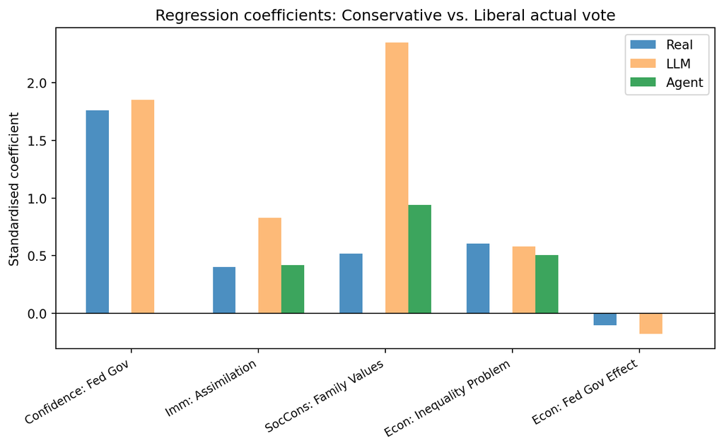

## Summary

[output not shown]

Note: CES21 combines Campaign Period Survey (CPS, `cps21_`) and Post-Election Survey (PES, `pes21_`) modules. Complete cases (n=9,418) are respondents who answered both and provided substantive (non-DK) responses on all 21 selected variables. Vote choice in PES reflects **actual** September 20, 2021 election vote, not vote intention.